# Assignment 5

Malte Genschow

24 12 2021

#### Code of Conduct

You will only successfully complete this assignment if you adhere to the following rules and guidelines. You are allowed to work in groups, however,

- the work submitted must be yours.
- the code must be your own.
- you must make clear whom you worked with.

**By submitting this assignment I agree to the above mentioned terms.**

### General Setup:

##### Clear Workspace

```r
rm(list = ls())
```

### 1. GitHub

The code for this assignment can be found in [this repository](https://github.com/MGenschow/DS400_Assignment_5).

### 2. Getting to know the API

- The rate limits for the [Ticketmaster Discovery API](https://developer.ticketmaster.com/products-and-docs/apis/getting-started/) is 5000 API calls per day and rate limitation of 5 requests per second.
- An API key has been obtained from the [API Explorer](https://developer.ticketmaster.com/api-explorer/v2/) and saved in a separate document. This document was added to the.gitignore file such that the secret key is not shared on Github. This key is sourced in the following code:

```r
source('ticketmaster_secret_key.R')
```

### 3. Basic Interacting with the API

##### Load the required packages

```r
library(httr)
library(jsonlite)
library(dplyr)
library(ggplot2)
```

##### Create Endpoint URL

```r
country_code = 'DE'
url = paste('https://app.ticketmaster.com/discovery/v2/venues?apikey=', key, '&locale=*&countryCode=' , country_code, sep='')
url
```

```
## [1] "https://app.ticketmaster.com/discovery/v2/venues?apikey=7elxdku9GGG5k8j0Xm8KWdANDgecHMV0&locale=*&countryCode=DE"
```

##### Get content from API and inspect

```r
response = GET(url)
content = content(response)
```

The resulting list of three contains all the information for 20 venues obtained from the API. This list of lists contains the information about the venue in the first entry *embedded* -> *venues*. In each of the 20 entries, one can find the name, city, postalCode, address, url, longitude, latitude and many more. The second entry ( *links* ) contains links to the current page, the next page and the last page for all the venues on the api. The last entry ( *page*) contains information about the number of entries at the current page, the number of entries in general (on all pages) and the total number of pages.

In the following only the relevant information per venue is extracted from the nested list:

```r
json_content = content(response, as='text')
venue_data = data.frame(fromJSON(json_content)[[1]][[1]])
venue_data = as.data.frame(venue_data[,c('name', 'city', 'postalCode', 'address', 'url', 'location')])
venue_data = do.call(data.frame, venue_data)
venue_data=venue_data %>% rename(
  city = name.1,
  address = line1,
  longitude = location.longitude,
  latitude = location.latitude
)
glimpse(venue_data)
```

```
## Rows: 20
## Columns: 7
## $ name       <chr> "Gruenspan", "Philharmonie (Großer Saal)", "Beatpol", "Mari~
## $ city       <chr> "Hamburg", "Berlin", "Dresden", "Dessau-Roßlau", "Munich", ~
## $ postalCode <chr> "22767", "10785", "01157", "06844", "80809", NA, "12435", "~
## $ address    <chr> "Grosse Freiheit 58", "Herbert-von-Karajan-Straße 1", "Altb~
## $ url        <chr> "http://www.ticketmaster.de/venue/287155", "https://www.tic~
## $ longitude  <chr> "9.958075", "13.36896", "13.67471", "12.24645", "11.55092",~
## $ latitude   <chr> "53.551885", "52.51007", "51.06498", "51.83364", "48.17543"~
```

### Advanced Interaction with the API

```r
content[[3]]
```

```
## $size
## [1] 20
##
## $totalElements
## [1] 12573
##
## $totalPages
## [1] 629
##
## $number
## [1] 0
```

1. In order to construct the loop, one has to find the number of pages for a given page size. This will be the running index in the loop that will be constructed later.

```r
country_code = 'DE'
size = 500
url = paste('https://app.ticketmaster.com/discovery/v2/venues?apikey=', key, '&locale=*&size=',size,'&countryCode=' , country_code, sep='')
response = GET(url)
content = content(response)
total_pages = content[[3]][[3]]
total_pages
```

```
## [1] 26
```

2. Now the loop can be constructed. Data cleaning will happen inside the loop, such that in each iteration, 500 new entries will be brought into tidy format and appended to the final dataframe.

```r
all_data = data.frame()
for (page in 0:(total_pages-1)){
  url = paste('https://app.ticketmaster.com/discovery/v2/venues?apikey=', key, '&locale=*&size=',size,'&page=',page,'&countryCode=' , country_code, sep='')
  response = GET(url)
  #parse to json
  content = content(response)
  json_content = content(response, as='text')
  # parse to r-dataframe
  venue_data = data.frame(fromJSON(json_content)[[1]][[1]])
  # subset to columns needed
  venue_data = as.data.frame(venue_data[,c('name', 'city', 'postalCode', 'address', 'url', 'location')])
  # collapse nested structure in the location (lat and lon)
  venue_data = do.call(data.frame, venue_data)
  # rename columns
  venue_data= venue_data %>% rename(
  city = name.1,
  longitude = location.longitude,
  latitude = location.latitude
  )
  # rename address columns conditionally
  if ('line1' %in% names(venue_data))
    venue_data= venue_data %>% rename(
      address = line1)
  if ('address.line1' %in% names(venue_data))
    venue_data= venue_data %>% rename(
      address = address.line1)
  # combine all data together
  all_data = bind_rows(all_data, venue_data)
  # Add sleep in each iteration such that rate limits are not exceeded
  Sys.sleep(0.4)
}
```

Quick look at the resulting data

```r
all_data$address.line2 = NULL
all_data[,c('postalCode', 'longitude', 'latitude')] = sapply(all_data[,c('postalCode', 'longitude', 'latitude')], as.numeric)
glimpse(all_data)
```

```
## Rows: 12,573
## Columns: 7
## $ name       <chr> "Gruenspan", "Philharmonie (Großer Saal)", "Beatpol", "Mari~
## $ city       <chr> "Hamburg", "Berlin", "Dresden", "Dessau-Roßlau", "Munich", ~
## $ postalCode <dbl> 22767, 10785, 1157, 6844, 80809, NA, 12435, 79108, 70192, 7~
## $ address    <chr> "Grosse Freiheit 58", "Herbert-von-Karajan-Straße 1", "Altb~
## $ url        <chr> "http://www.ticketmaster.de/venue/287155", "https://www.tic~
## $ longitude  <dbl> 9.958075, 13.368960, 13.674710, 12.246450, 11.550920, 9.194~
## $ latitude   <dbl> 53.55188, 52.51007, 51.06498, 51.83364, 48.17543, 48.89085,~
```

### Visualizing the extracted data

```r
# Exclude obvious faulty coordinates
is.na(all_data['longitude']) <-  all_data['longitude'] < 5.866944 | all_data['longitude'] >15.043611
is.na(all_data['latitude']) <-  all_data['latitude'] < 47.271679 | all_data['latitude'] >55.0846
all_data$latitude = ifelse(is.na(all_data$longitude),NA,all_data$latitude)
all_data$longitude = ifelse(is.na(all_data$latitude),NA,all_data$longitude)
```

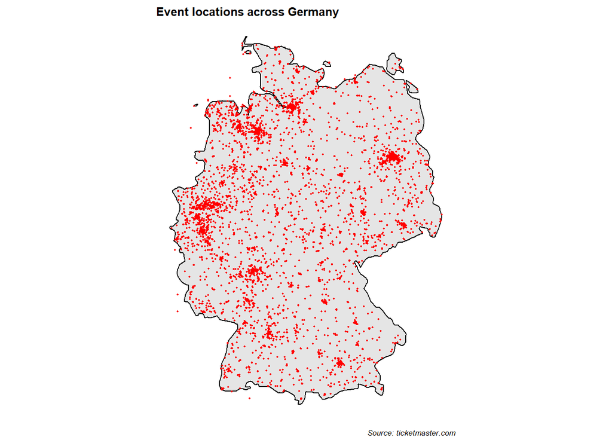

```r
# plot the data on a map
ggplot() +
  geom_polygon(
  aes(x = long, y = lat, group = group), data = map_data("world", region = "Germany"),
    fill = "grey90",color = "black") +
  theme_void() + coord_quickmap() +
  labs(title = "Event locations across Germany", caption = "Source: ticketmaster.com") +
  theme(title = element_text(size=8, face='bold'),
  plot.caption = element_text(face = "italic"))+
  geom_point(aes(x=longitude, y=latitude), data=all_data, size=0.4, color='red', na.rm=T)
```

### Repeat the task for Spain

```r
country_code = 'ES'
size = 500
url = paste('https://app.ticketmaster.com/discovery/v2/venues?apikey=', key, '&locale=*&size=',size,'&countryCode=' , country_code, sep='')
response = GET(url)
content = content(response)
total_pages = content[[3]][[3]]
total_pages
```

```
## [1] 7
```

```r
all_data = data.frame()
for (page in 0:(total_pages-1)){
  url = paste('https://app.ticketmaster.com/discovery/v2/venues?apikey=', key, '&locale=*&size=',size,'&page=',page,'&countryCode=' , country_code, sep='')
  response = GET(url)
  #parse to json
  content = content(response)
  json_content = content(response, as='text')
  # parse to r-dataframe
  venue_data = data.frame(fromJSON(json_content)[[1]][[1]])
  # subset to columns needed
  venue_data = as.data.frame(venue_data[,c('name', 'city', 'postalCode', 'address', 'url', 'location')])
  # collapse nested structure in the location (lat and lon)
  venue_data = do.call(data.frame, venue_data)
  # rename columns
  venue_data= venue_data %>% rename(
  city = name.1,
  longitude = location.longitude,
  latitude = location.latitude
  )
  # rename address columns conditionally
  if ('line1' %in% names(venue_data))
    venue_data= venue_data %>% rename(
      address = line1)
  if ('address.line1' %in% names(venue_data))
    venue_data= venue_data %>% rename(
      address = address.line1)
  # combine all data together
  all_data = bind_rows(all_data, venue_data)
  # Add sleep in each iteration such that rate limits are not exceeded
  Sys.sleep(0.4)
}
```

Quick look at the resulting data

```r
all_data$address.line2 = NULL
all_data[,c('postalCode', 'longitude', 'latitude')] = sapply(all_data[,c('postalCode', 'longitude', 'latitude')], as.numeric)
glimpse(all_data)
```

```
## Rows: 3,197
## Columns: 7
## $ name       <chr> "Estadio La Cartuja de Sevilla", "Oasis Club Teatro", "Sala~
## $ city       <chr> "Sevilla", "Zaragoza", "Madrid", "Salamanca", "Madrid", "Va~
## $ postalCode <dbl> 41092, NA, 28015, 37004, 28009, 46009, 9001, 8018, 8907, 46~
## $ address    <chr> "Isla de la Cartuja", "Calle Basilio Boggiero, 28", "C. de ~
## $ url        <chr> "https://www.ticketmaster.es/venue/estadio-la-cartuja-de-se~
## $ longitude  <dbl> -6.00722, -0.88562, -3.71369, -5.65044, -3.67580, -0.38775,~
## $ latitude   <dbl> 37.39861, 41.65515, 40.43528, 40.97916, 40.42394, 39.48123,~
```

### Visualizing the extracted data

The extremum coordinates used below can be found [here](https://en.wikipedia.org/wiki/List_of_extreme_points_of_Spain)

```r
# Exclude obvious faulty coordinates
is.na(all_data['longitude']) <-  all_data['longitude'] < -18.15 | all_data['longitude'] >4.316667
is.na(all_data['latitude']) <-  all_data['latitude'] < 27.633333 | all_data['latitude'] >43.783333
all_data$latitude = ifelse(is.na(all_data$longitude),NA,all_data$latitude)
all_data$longitude = ifelse(is.na(all_data$latitude),NA,all_data$longitude)
```

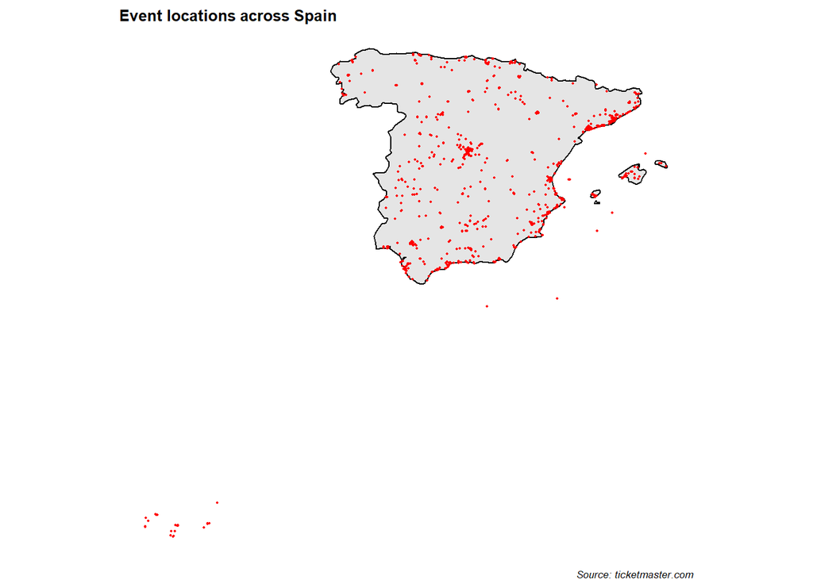

```r
# plot the data on a map
ggplot() +
  geom_polygon(
  aes(x = long, y = lat, group = group), data = map_data("world", region = "Spain"),
    fill = "grey90",color = "black") +
  theme_void() + coord_quickmap() +
  labs(title = "Event locations across Spain", caption = "Source: ticketmaster.com") +
  theme(title = element_text(size=8, face='bold'),
  plot.caption = element_text(face = "italic")) +
  geom_point(aes(x=longitude, y=latitude), data=all_data, size=0.4, color='red', na.rm=T)
```